# Special Topics: Missing data & Subsetting

COMM 3710

2021-03-08

# 1 Missing Data

## 1.1 How to handle `NA`

In R, missing data is represented by `NA`, which stands for “Not Available.” There can be many reasons for missing data. For example, a participant may have skipped a question on purpose or by accident, and therefore has no recorded value on a given variable. We call such unavailable data “missing data.” Missing data is a problem that comes up frequently in data analysis.

We’ll create a small hypothetical data set to use as an example for this tutorial. Below the data frame `week` consists of three variables: `day` (day of the week), `temp` (temperature reading for each day), and `mile` (miles run per day). The thermometer broke on Tuesday so there was no recording for that day. On Thursday I forgot to wear my AppleWatch so I didn’t know how many miles I ran that day.

You can copy and paste the following lines and run in your RStudio to create the data frame `week`.

```r
day <- c("Sun", "Mon", "Tue", "Wed", "Thur", "Fri", "Sat") #creating a vector: days of the week
temp <- c(32.3, 38.7, NA, 40.1, 37.6, 33.5, 31.7) #creating a vector: temperature readings
mile <- c(3.4, 4.5, 5.5, 5.5, NA, 4.2, 4.5) #creating a vector: miles run per day
week <- data.frame(day, temp, mile) #creating a data frame with three variables: "day", "temp", "mile"
```

You can view this very small data frame by running:

```r
week
```

which should look like:

| day | temp | mile |
| --- | --- | --- |
| Sun | 32.3 | 3.4 |
| Mon | 38.7 | 4.5 |
| Tue | NA | 5.5 |
| Wed | 40.1 | 5.5 |
| Thur | 37.6 | NA |
| Fri | 33.5 | 4.2 |
| Sat | 31.7 | 4.5 |

You can also view the names and types of the variables in this data frame:

```r
names(week)
```

```
## [1] "day"  "temp" "mile"
```

```r
str(week)
```

```
## 'data.frame':    7 obs. of  3 variables:
##  $ day : chr  "Sun" "Mon" "Tue" "Wed" ...
##  $ temp: num  32.3 38.7 NA 40.1 37.6 33.5 31.7
##  $ mile: num  3.4 4.5 5.5 5.5 NA 4.2 4.5
```

Now, suppose we are interested in the average temperature for the week. To compute the mean, we use the function `mean()`.

```r
mean(week$temp)
```

After running it, we got this:

```
## [1] NA
```

That is because the variable `temp` contains one missing value `NA`, and in the command above, we did not tell R what to do with the missing value. We introduce two ways of handling missing data in such situations.

### 1.1.1 Use the `(, na.rm = TRUE)` argument

Now, try this:

```r
mean(week$temp, na.rm = TRUE)
```

```
## [1] 35.65
```

So, the average temperature for the week excluding Tuesday is `35.65`.

> `na.rm` - a logical value indicating whether NA values should be stripped before the computation proceeds.

By default `na.rm =` is set to `FALSE`. You will need to specify it as `TRUE` to let R know that you would like the `NA`s to be **ignored** by the command (i.e., `NA`s still exist in the data; they are just not included in the analysis).

### 1.1.2 Use the `na.omit()` function

Another way of dealing with missing data is to create a new data set by excluding cases that contain `NA`s. The function to use is `na.omit()`, which tells R to remove cases that contain any `NA` value.

```r
week_new <- na.omit(week)
```

Now check this new object:

```r
week_new
```

|  | day | temp | mile |
| --- | --- | --- | --- |
| 1 | Sun | 32.3 | 3.4 |
| 2 | Mon | 38.7 | 4.5 |
| 4 | Wed | 40.1 | 5.5 |
| 6 | Fri | 33.5 | 4.2 |
| 7 | Sat | 31.7 | 4.5 |

As you can see, there are only 5 rows of data in `week_new`. Note that the rows for both Tuesday and Thursday have been removed because Tuesday contained `NA` on the variable `temp`, and Thursday had `NA` for `mile`.

Since `week_new` has no missing data, we can directly use the `mean()` and other computation functions.

```r
mean(week_new$temp)
range(week_new$temp)
sum(week_new$temp) # sum of all the temperature readings
```

You should get:

```
## [1] 35.26
```

```
## [1] 31.7 40.1
```

```
## [1] 176.3
```

If you want to avoid creating new objects, you can also directly apply `mean()` to what is filtered out by `na.omit()`, as follows:

```r
mean(na.omit(week)$temp)
```

```
## [1] 35.26
```

You may have noticed that running `mean(week_new$temp)` or `mean(na.omit(week)$temp)` returned a different result than what we did with the first approach– `mean(week$temp, na.rm = TRUE)`. Why is it?

**Answer**

`na.omit()` removes all the observations with a missing value – so observations for both Tuesdays and Thursdays are excluded. On the other hand, `(, na.rm = TRUE)` only ignores the NAs for the variable being analyzed. So `mean(week$temp, na.rm = TRUE)` computes the mean based on 6 observations– after excluding the NA for `temp` only. In contrast, `mean(week_new$temp)` or equivalently `mean(na.omit(week)$temp)` computes the mean temperature based on 5 observations after removing NAs for both `temp` and `mile`, even though only `temp` is being analyzed here.

```
Try it on your own:
What if we want to get the average of miles run per day for the week?
```

**Answer**

```r
mean(week$mile, na.rm = TRUE)
#OR
mean(week_new$mile)
#OR
mean(na.omit(week)$mile)
```

You should get the following answers (The first one is slightly different than the other two because they involve different observations, as is explained above).

```
## [1] 4.6
```

```
## [1] 4.42
```

```
## [1] 4.42
```

Back to top

## 1.2 Turning values into `NA`

Sometimes a response is recorded by researchers in a survey, but the response category is of little meaning to the goal of your analysis. In such cases you may want to exclude such responses from the analysis.

For example, in a survey assessing the public’s attitude toward Covid vaccination, where “1 = strongly oppose” and “5 = strongly support”, the researchers also offered these categories that participants could choose:  
- “77 = No opinion”  
- “88 = Unsure/undecided”  
- “99 = I don’t know anything about the topic”

Let’s quickly create a hypothetical data set with 20 participants. Just copy and paste the lines below and run them in your RStudio:

```r
id <- 1:20 #ID of participants
att <- c(1, 4, 1, 99, 2, 3, 5, 77, 2, 4,
        5, 3, 88, 3, 2, 4, 1, 2, 3, 1) #attitude toward vaccination
covid <- data.frame(id, att) #data frame with these two variables
```

You can see the data frame “covid” by running `covid`.

**See `covid` here**

| id | att |
| --- | --- |
| 1 | 1 |
| 2 | 4 |
| 3 | 1 |
| 4 | 99 |
| 5 | 2 |
| 6 | 3 |
| 7 | 5 |
| 8 | 77 |
| 9 | 2 |
| 10 | 4 |
| 11 | 5 |
| 12 | 3 |
| 13 | 88 |
| 14 | 3 |
| 15 | 2 |
| 16 | 4 |
| 17 | 1 |
| 18 | 2 |
| 19 | 3 |
| 20 | 1 |

We can run frequency and see values of the variable `att`.

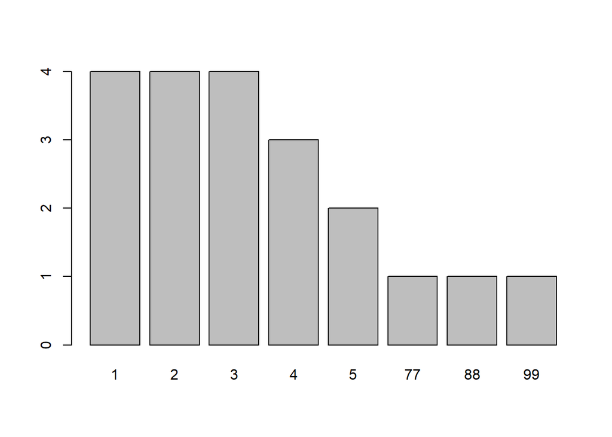

```
## covid$att
##       Frequency Percent
## 1             4      20
## 2             4      20
## 3             4      20
## 4             3      15
## 5             2      10
## 77            1       5
## 88            1       5
## 99            1       5
## Total        20     100
```

```r
freq(covid$att)
```

If we compute the mean without any data treatment, the values 77, 88, 99 would count as meaningful numbers just as 1 - 5, which would wrongly skew the distribution:

```r
mean(covid$att)
```

```
## [1] 15.5
```

…you get a result that is not interpretable for the given 5-point attitude scale. The average was pulled much higher by the three values 77, 88, 99, which were not supposed to represent the attitude strength.

So, you should remove such responses from your analysis by treating them as missing data. We can simply assign the value `NA` to replace the values `77`, `88`, and `99`.

You can do it one at a time:

```r
covid$att[covid$att == 77] <- NA
covid$att[covid$att == 88] <- NA
covid$att[covid$att == 99] <- NA
```

**Other ways to replace with `NA`**

Or you can use one command by using the “OR” logical connector `|`:

```r
covid$att[covid$att == 77 | covid$att == 88 | covid$att == 99] <- NA

## That is, if the value of "att" is 77 OR 88 OR 99, assign `NA` to the variable of "att". In other words, replace these three values with `NA`.
```

Or, since 77, 88, 99 are the only three values outside the 1 - 5 range, you can also simply write:

```r
covid$att[covid$att > 5] <- NA
```

Run the frequency and see whether you’ve replaced them successfully. You should see that there are now three `NA`s in the frequency table and all the other values range from 1 - 5.

**See here for results of frequency**

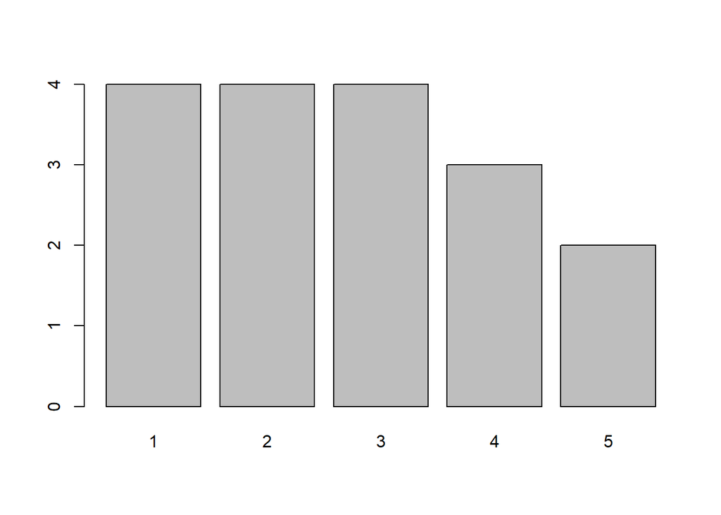

```
## covid$att
##       Frequency Percent Valid Percent
## 1             4      20         23.53
## 2             4      20         23.53
## 3             4      20         23.53
## 4             3      15         17.65
## 5             2      10         11.76
## NA's          3      15
## Total        20     100        100.00
```

```r
freq(covid$att)
```

Now you can get the average attitude toward vaccination by `mean()`. (Recall the last section on how to handle `NA`s in the analysis.)

```r
mean(covid$att, na.rm = TRUE)
```

```
## [1] 2.705882
```

Back to top

# 2 Creating a Subset of Your Data

From the data sets you’ve worked with so far, you can tell that they largely have these structural characteristics:

- Each variable has its own column.
- Each observation has its own row.
- Each value has its own cell.

[source](https://d33wubrfki0l68.cloudfront.net/6f1ddb544fc5c69a2478e444ab8112fb0eea23f8/91adc/images/tidy-1.png)

For specific goals of analyses, We often need to create a subset of the data by selecting columns (variables), or rows (observations), or both.

## 2.1 Selecting Columns (Variables)

For your group project, if you know your analyses will be only limited to a few variables, you can create a smaller data set that contains only these variables. It’s not required, but this way you will not overburden R with a large data set, and you will also have a cleaner view of the variables you are working with.

To select columns, there are a few ways of doing it:

1. Use `[ ]` to index what are the columns you would like to select. The generic formula looks like:

`newdata <- fulldata[, c("var1", "var2", "var3", ...)]`

For the `week` data frame we created earlier, if we only want to keep two variables, the temperature and day of the week,

```r
week_temp <- week[, c("day", "temp")]
week_temp
```

2. Use `subset()` command with `select =` argument that specifies the variables to be included.

`newdata <- subset(fulldata, select = c(var1, var2, var3, ...))`

```r
week_temp <- subset(week, select = c(day, temp))
week_temp
```

3. Use `select()` command, which is part of the `dplyr` package.

`newdata <- select(fulldata, var1, var2, var3, ...)`

```r
library(dplyr) #install the package first if you haven't: install.packages("dplyr")
week_temp <- select(week, day, temp)
```

These above three ways should give you the same data frame:

```r
week_temp
```

| day | temp |
| --- | --- |
| Sun | 32.3 |
| Mon | 38.7 |
| Tue | NA |
| Wed | 40.1 |
| Thur | 37.6 |
| Fri | 33.5 |
| Sat | 31.7 |

Back to top

## 2.2 Selecting Rows (Observations)

To use the `covid` data frame that we created above as an example:

If we are only interested in participants whose attitude toward the vaccine was on the favorable side (i.e., above the mid-point on the 1-5 point scale), we can create a subset `covid_fav`:

1. Use `[ ]` to specify the logical conditions:

The generic form looks like: `newdata <- fulldata[variable meeting conditions, ]`

On the `covid` data frame:

```r
covid_fav <- covid[covid$att > 3, ]  ##[row selection, keep all columns]
covid_fav
```

2. Use `subset()` command:

Generic: `newdata <- subset(fulldata, variable meeting certain conditions)`

On the `covid` data frame:

```r
covid_fav <- subset(covid, att > 3)
covid_fav
```

3. Use `filter()` command as part of the `dplyr` package.

Generic: `newdata <- filter(fulldata, variables meeting certain conditions)`

On the `covid` data frame:

```r
covid_fav <- filter(covid, att > 3)
covid_fav
```

```
Try it on your own:

How to create a subset of the `week` data without the variable `temp` and only observations on weekdays?
```

**Answer**

- Without the variable “temp” – selecting columns (i.e., variables) “day” and “mile”
- Only observations on weekdays – selecting rows (i.e., observations) excluding Sat and Sun

```r
smalldata <- subset(week, day != "Sun" & day != "Sat", select = c(day, mile))
smalldata
```

```
##    day mile
## 2  Mon  4.5
## 3  Tue  5.5
## 4  Wed  5.5
## 5 Thur   NA
## 6  Fri  4.2
```

OR

```r
smalldata <- week[week$day != "Sun" & week$day != "Sat", c("day", "mile")] ## [row selection, column selection]
smalldata
```

```
##    day mile
## 2  Mon  4.5
## 3  Tue  5.5
## 4  Wed  5.5
## 5 Thur   NA
## 6  Fri  4.2
```

OR

```r
smalldata <- week %>%
            select(day, mile) %>%
            filter(day != "Sun" & day != "Sat")
smalldata
```

```
##    day mile
## 1  Mon  4.5
## 2  Tue  5.5
## 3  Wed  5.5
## 4 Thur   NA
## 5  Fri  4.2
```

Back to top